# guion12

## Datos

Utilizaremos las medidas de expresión génica del archivo salmon.merged.gene_counts.tsv. Los datos proceden de 12 genotecas de RNA-seq de lecturas emparejadas, de muestras de Drosophila melanogaster de dos orígenes geográficos (Panamá y Maine) y dos tratamientos de temperatura (low y high).

El archivo dme_elev_samples.tsv, una tabla que indica a qué región y tratamiento pertenece cada muestra.

Los dos archivos deben estar guardados en la carpeta de datos.

##Exploración de los datos

```r
muestras <- read.table('../../data/dme_elev_samples.tsv', header = TRUE)
genex <- read.table('../../data/salmon.merged.gene_counts.tsv',
                    header = TRUE)
```

#Ejercicio 1 Usa la función paste() para añadir una columna a muestras que contenga la población y la temperatura unidas por _.

```r
muestras$group <- paste(muestras$population, muestras$temp, sep = "_")
head(muestras)
```

```
      sample population temp      group
1 SRR1576457      maine  low  maine_low
2 SRR1576458      maine  low  maine_low
3 SRR1576459      maine  low  maine_low
4 SRR1576460      maine high maine_high
5 SRR1576461      maine high maine_high
6 SRR1576462      maine high maine_high
```

¿Cuál es el número total de lecturas por muestra?

```r
colSums(genex[, 3:14])
```

```
SRR1576457 SRR1576458 SRR1576459 SRR1576460 SRR1576461 SRR1576462 SRR1576463
  28252778   21565448   29471559   27692134   26953900   29368135   29706071
SRR1576464 SRR1576465 SRR1576514 SRR1576515 SRR1576516
  26757043   26596118   30950499   25563787   24401671
```

Se observa el nombre de la muestra con el número total de lecturas debajo de su respectivo nombre. por ejemplo en el caso de la muestra SRR1576457 hay un total de 28252778 lecturas. Si quisieramos el numero total de lecturas se podría hacer sum(colSums(genex[, 3:14])) o si quisieramos el numero medio de lecturas mean(colSums(genex[, 3:14]))

¿Los recuentos tienen distribuciones parecidas entre muestras?

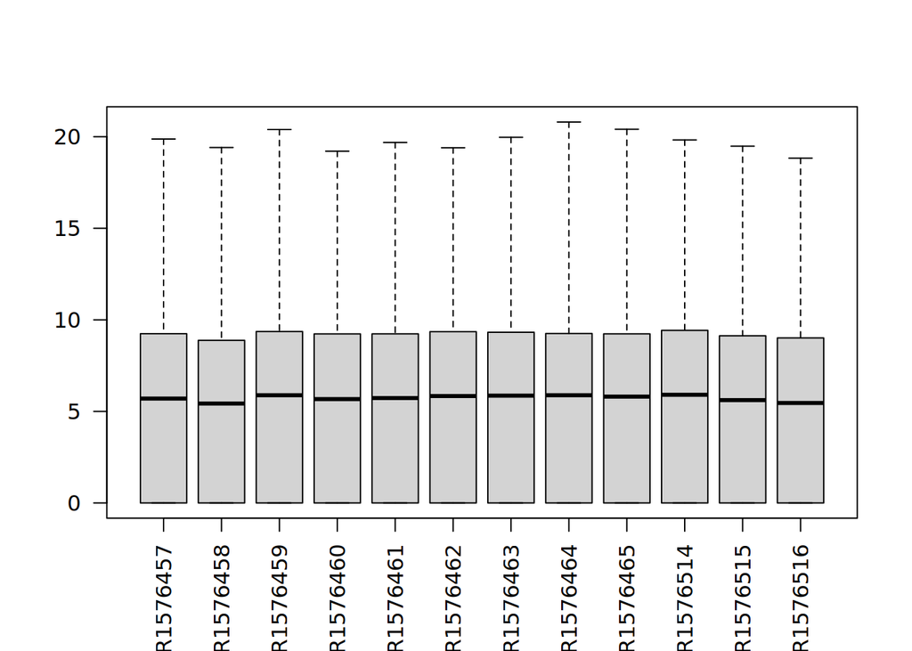

```r
boxplot(log2(genex[, 3:14] + 1), las = 2)
```

Sí, tienen distribuciones similares, puesto que tienen cajas similares, medias similares y rangos similares.

¿Cuántos genes no se expresan en absoluto en ninguna de las muestras?

```r
sum(rowSums(genex[, 3:14]) == 0)
```

```
[1] 4722
```

El total de genes que no se expresan en ninguna de las muestras es de 4722.

##Crear el objeto de clase DESeqDataSet

Para crear un objeto de clase DESeqDataSet necesitamos que las filas de la tabla muestras estén en el mismo orden que las columnas en genex. La función DESeqDataSetFromMatrix() necesita que los recuentos sean una matriz, no un marco de datos. Y en muestras debe haber factores.

```r
suppressMessages(library('DESeq2'))
all(names(genex)[3:14] == muestras$sample)
```

```
[1] TRUE
```

```r
# Pasamos la columna "sample" a nombres de fila:
row.names(muestras) <- muestras$sample
# Eliminamos la columna "sample":
muestras$sample <- NULL
# Y convertimos "population" y "temp" en factores:
muestras$population <- factor(muestras$population,
                              levels = c('maine', 'panama'))
muestras$temp       <- factor(muestras$temp,
                              levels = c('low', 'high'))
muestras
```

```
           population temp       group
SRR1576457      maine  low   maine_low
SRR1576458      maine  low   maine_low
SRR1576459      maine  low   maine_low
SRR1576460      maine high  maine_high
SRR1576461      maine high  maine_high
SRR1576462      maine high  maine_high
SRR1576463     panama  low  panama_low
SRR1576464     panama  low  panama_low
SRR1576465     panama  low  panama_low
SRR1576514     panama high panama_high
SRR1576515     panama high panama_high
SRR1576516     panama high panama_high
```

Aunque no hacía falta definir los niveles de los factores, lo indico porque es un buen momento para definir manualmente su orden (por defecto se ordenan alfabéticamente). El orden de los niveles determina qué nivel actúa como referencia en los contrastes estadísticos (el primero). Esto resultaría importante, por ejemplo, al comparar tratamientos respecto de un control.

Los datos de recuento deben ser números enteros y en forma de matriz

```r
row.names(genex) <- genex$gene_name
genex$gene_name <- NULL
genex$gene_id   <- NULL
genex <- round(as.matrix(genex))
```

```r
dds1 <- DESeqDataSetFromMatrix(
   countData = genex,
   colData = muestras,
   design = ~ population + temp
)
dds1
```

```
class: DESeqDataSet
dim: 24254 12
metadata(1): version
assays(1): counts
rownames(24254): 7SLRNA:CR32864 a ... RR51477 Bari1{}RR51478
rowData names(0):
colnames(12): SRR1576457 SRR1576458 ... SRR1576515 SRR1576516
colData names(3): population temp group
```

NOTA Los objetos DESeqDataSet pueden contener información sobre las coordenadas cromosómicas de los genes o tránscritos, si se construyen a partir de otro tipo de datos.

##Pre-filtrado

Una fracción importante de genes no se están expresando en ningúna muestra. Aunque el filtrado no es necesario, ayuda a reducir la memoria ocupada por dds1:

```r
keep <- rowSums(counts(dds1)) > 0
dds1 <- dds1[keep, ]
```

##Expresión diferencial

```r
dds1 <- DESeq(dds1)
```

```r
res <- results(dds1)
res
```

```
log2 fold change (MLE): temp high vs low
Wald test p-value: temp high vs low
DataFrame with 19508 rows and 6 columns
                baseMean log2FoldChange     lfcSE       stat      pvalue
               <numeric>      <numeric> <numeric>  <numeric>   <numeric>
7SLRNA:CR32864   346.333      0.5918974 1.3301901   0.444972 0.656339979
a                555.596     -0.2730041 0.0718487  -3.799710 0.000144866
abd-A            531.996     -0.0286785 0.0789218  -0.363379 0.716321732
Abd-B            634.760     -0.1083918 0.0771241  -1.405421 0.159896272
Abl             1654.842     -0.1328055 0.0746580  -1.778851 0.075264257
...                  ...            ...       ...        ...         ...
RR51007          4.90906      3.8596869  2.972471  1.2984773 1.94123e-01
RR51048         16.60710     -0.8973071  0.341603 -2.6267541 8.62036e-03
RR51093         36.93279      0.0660523  1.685323  0.0391927 9.68737e-01
RR51475        159.62678     -2.6058194  1.875172 -1.3896429 1.64637e-01
RR51477         70.83394      1.6927986  0.192437  8.7966393 1.40975e-18
                      padj
                 <numeric>
7SLRNA:CR32864  0.81170166
a               0.00154573
abd-A           0.85146289
Abd-B           0.33849217
Abl             0.20046220
...                    ...
RR51007        3.82417e-01
RR51048        4.01745e-02
RR51093        9.84464e-01
RR51475        3.44815e-01
RR51477        2.06427e-16
```

# Ejercicio 3

Mira la ayuda de results() y genera también la tabla de resultados para el contraste entre las dos regiones de procedencia de las moscas.

```r
res_pop <- results(dds1, contrast = c("population", "panama", "maine"))
res_pop
```

```
log2 fold change (MLE): population panama vs maine
Wald test p-value: population panama vs maine
DataFrame with 19508 rows and 6 columns
                baseMean log2FoldChange     lfcSE      stat      pvalue
               <numeric>      <numeric> <numeric> <numeric>   <numeric>
7SLRNA:CR32864   346.333     -0.2116106 1.3301901 -0.159083   0.8736035
a                555.596     -0.1114459 0.0718333 -1.551452   0.1207935
abd-A            531.996      0.0460822 0.0789226  0.583891   0.5592939
Abd-B            634.760     -0.0424386 0.0771227 -0.550274   0.5821315
Abl             1654.842     -0.1477705 0.0746581 -1.979298   0.0477825
...                  ...            ...       ...       ...         ...
RR51007          4.90906       2.118240  2.970241  0.713154 0.475750370
RR51048         16.60710      -1.274560  0.344507 -3.699659 0.000215889
RR51093         36.93279      -0.886468  1.685327 -0.525992 0.598893951
RR51475        159.62678       0.121496  1.875169  0.064792 0.948339648
RR51477         70.83394      -0.187567  0.188818 -0.993376 0.320526881
                     padj
                <numeric>
7SLRNA:CR32864   0.966480
a                0.449954
abd-A            0.838008
Abd-B            0.850233
Abl              0.288737
...                   ...
RR51007        0.79163008
RR51048        0.00812377
RR51093        0.85672953
RR51475        0.98600817
RR51477        0.67811881
```

Usa summary() sobre los resultados para ver el número de genes diferencialmente expresados entre cada par de condiciones.

```r
summary(res)
```

```
out of 19508 with nonzero total read count
adjusted p-value < 0.1
LFC > 0 (up)       : 2418, 12%
LFC < 0 (down)     : 2336, 12%
outliers [1]       : 90, 0.46%
low counts [2]     : 3018, 15%
(mean count < 2)
[1] see 'cooksCutoff' argument of ?results
[2] see 'independentFiltering' argument of ?results
```

```r
summary(res_pop)
```

```
out of 19508 with nonzero total read count
adjusted p-value < 0.1
LFC > 0 (up)       : 623, 3.2%
LFC < 0 (down)     : 634, 3.2%
outliers [1]       : 90, 0.46%
low counts [2]     : 3018, 15%
(mean count < 2)
[1] see 'cooksCutoff' argument of ?results
[2] see 'independentFiltering' argument of ?results
```

Estos dos bloques expresan el efecto de la temperatura, el primer bloque (high vs low), y el efecto de población (panamá vs maine), en el segundo. En el primer resultado se interpreta que hay 2418 genes más expresados en high que en low y 2336 genes más expresados en low que en high. Por su parte, en el segundo bloque se observa un menor número de genes expresados de manera diferencia. Se puede concluir que la temperatura tiene un efecto mucho mayor que la población sobre la expresión génica.

¿Cuál es la tasa de falsos positivos (FDR)?

En la orden anterior se observa la línea:adjusted p-value < 0.1, por lo tanto, se espera que hasta un 10% sean falsos positivos.

## Gráficas

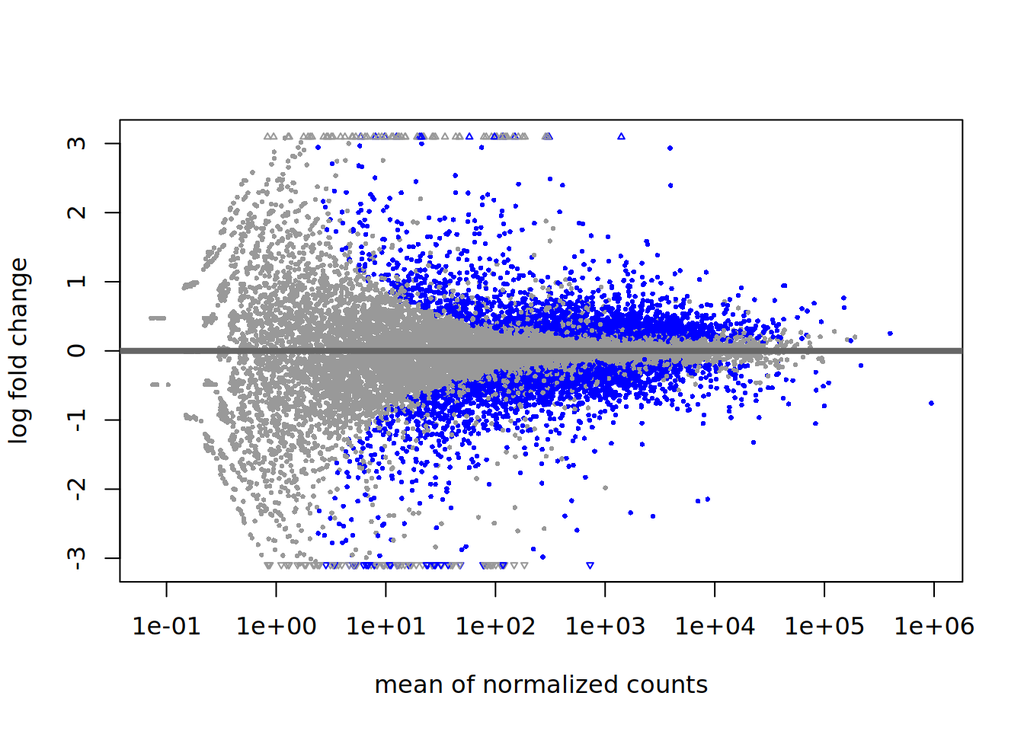

```r
plotMA(res)
```

Los genes con niveles de expresión más bajos producen resultados más ruidosos (la varianza es mayor). La función lfcShrink() contrae (shrink) las estimaciones de los efectos (log fold change) para reducir el ruido y hacer el resultado más realista:

```r
resShrink <- lfcShrink(dds1, coef = 'temp_high_vs_low',
                       type = 'normal')
```

```
using 'normal' for LFC shrinkage, the Normal prior from Love et al (2014).

Note that type='apeglm' and type='ashr' have shown to have less bias than type='normal'.
See ?lfcShrink for more details on shrinkage type, and the DESeq2 vignette.
Reference: https://doi.org/10.1093/bioinformatics/bty895
```

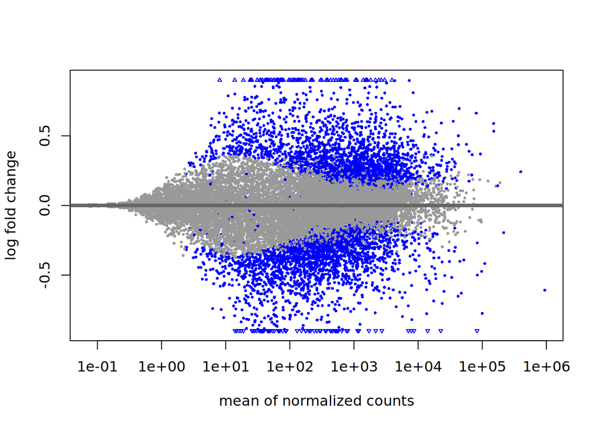

```r
plotMA(resShrink)
```